# Effect Heterogeneity

In this chapter, we introduce the **causal moderation** framework in **fect**, which allows researchers to formally model how treatment effects vary with a moderator variable. We distinguish between two conceptually distinct quantities of interest — *effect modification* and *causal moderation* — and show how **fect** estimates each. This chapter draws on the theoretical framework in @ZQX2025. Download the R code used in this chapter here.

```r
library(fect)
data(fect)
```

## Conceptual Framework

A prevalent approach for examining treatment effect heterogeneity in political science is the two-way fixed effects (TWFE) model with a multiplicative interaction term — the *linear interaction model*:
$$Y_{it} = \beta_0 + \tau\, D_{it}\, M_{it} + \beta_D\, D_{it} + \beta_M\,
M_{it} + \beta_X\, X_{it} + \alpha_i + \lambda_t + \epsilon_{it}$$
where $Y_{it}$ is the outcome, $D_{it}$ is the treatment indicator, $M_{it}$ is the moderator of interest, $X_{it}$ is a vector of covariates, and $\alpha_i, \lambda_t$ are unit and time fixed effects. The coefficient $\tau$ is typically interpreted as the extent to which the treatment effect varies with $M$.

Despite its widespread use, this model conflates two conceptually distinct questions:

1. **Effect modification**: How does the *average treatment effect* vary across subpopulations defined by the moderator?
2. **Causal moderation**: Does exogenously changing the moderator *causally alter* the treatment effect?

### Effect Modification

Effect modification describes a *correlational* relationship: the moderator serves as a signal for different underlying conditions. For example, if we study how railway access ($D$) affects separatist conflict ($Y$), per capita GDP ($M$) might serve as an effect modifier. Regions with low GDP may respond differently to railway access, but this is because GDP proxies for deeper economic structures — *experimentally increasing* GDP alone may not change the treatment effect.

Formally, the **Conditional Marginal Effect** (CME) for effect modification is:
$$\tau_{\text{em},t}^{\text{CME}}(m) = \mathbb{E}\!\big[Y_t(1, M_t) -
Y_t(0, M_t) \mid D_t = 1,\, M_t = m\big]$$
where $Y_t(d, M_t)$ is the potential outcome when treatment is set to $d$ while the moderator takes its naturally occurring value. The key feature is that $M_t$ remains at its *observed* level; we simply condition on it.

### Causal Moderation

Causal moderation describes a *mechanistic* relationship: the moderator has a direct causal influence on the treatment effect. For instance, the quality of democratic institutions ($M$) may directly protect minority rights, thereby *causing* a different reaction to a policy ($D$). Exogenously changing $M$ from “low” to “high” would genuinely alter the treatment effect.

Formally, the CME for causal moderation is:
$$\tau_{\text{cm},t}^{\text{CME}}(m) = \mathbb{E}\!\big[Y_t(1, m) - Y_t(0,
m) \mid D_t = 1\big]$$
where both the treatment $d$ and the moderator $m$ are *intervened upon*. Unlike effect modification, the moderator is set to a hypothetical value $m$, and we average over the treated population unconditionally.

### When Do They Coincide?

Under the **ignorability of $M$** assumption — i.e., there are no causal links between unobserved confounders $U$ and the moderator $M$, nor between $D$ and $M$, nor between $X$ and $M$ — the two estimands are numerically identical at the aggregate level. In practice, the divergence between the two estimates provides a diagnostic: if $\hat{\tau}_{\text{em}}^{\text{CME}}(m) \approx \hat{\tau}_{\text{cm}}^{\text{CME}}(m)$ for all $m$, the moderator primarily acts as a causal moderator; a large divergence suggests it functions more as an effect modifier (a proxy for other causal drivers).

### Aggregation

The period-specific CMEs are aggregated across time:
$$\tau_{\text{em}}^{\text{CME}}(m) = \sum_t \omega_t^{\text{em}}(m)\,
\tau_{\text{em},t}^{\text{CME}}(m), \quad
\tau_{\text{cm}}^{\text{CME}}(m) = \sum_t \omega_t^{\text{cm}}(m)\,
\tau_{\text{cm},t}^{\text{CME}}(m)$$
where $\omega_t^{\text{em}}(m)$ and $\omega_t^{\text{cm}}(m)$ are appropriate weights summing to one. The effect modification and causal moderation estimands are then:
$$\tau_{\text{em}}(m, m') = \tau_{\text{em}}^{\text{CME}}(m) -
\tau_{\text{em}}^{\text{CME}}(m'), \quad
\tau_{\text{cm}}(m, m') = \tau_{\text{cm}}^{\text{CME}}(m) -
\tau_{\text{cm}}^{\text{CME}}(m')$$

## Identification Assumptions

The identification strategy for both estimands relies on a Directed Acyclic Graph (DAG) representation of the data-generating process. Following @Pearl2009 and @imai2019, we use a DAG to separate identification from functional form.

### The NPSEM

Under the DGP assumption, the Non-Parametric Structural Equation Model (NPSEM) for any time period $t$ is:

$$\begin{aligned}
Y_{it} &= f_Y^t(D_{it}, M_{it}, X_{it}, U_{it}, \epsilon_{it}) \\
D_{it} &= f_D^t(D_{i1}, \ldots, D_{it-1}, M_{i1}, \ldots, M_{it},
X_{i1}, \ldots, X_{it}, U_{it}, \epsilon_{it}^D) \\
M_{it} &= f_M^t(M_{i1}, \ldots, M_{it-1}, X_{i1}, \ldots, X_{it},
U_{it}, \epsilon_{it}^M) \\
X_{it} &= f_X^t(X_{i1}, \ldots, X_{it-1}, U_{it}, \epsilon_{it}^X)
\\
U_{it} &= \alpha_i + \lambda_t
\end{aligned}$$

where $\epsilon_{it}, \epsilon_{it}^D, \epsilon_{it}^M, \epsilon_{it}^X$ are mutually independent disturbances. The composite $U_{it} = \alpha_i + \lambda_t$ captures unobserved confounding through additive unit and time effects.

Two key restrictions enable identification via differencing:

1. **No Feedback**: Past outcomes do not directly influence current treatments, moderators, or covariates (strict exogeneity).
2. **Additive Separability**: Unobserved confounders enter additively as $\alpha_i + \lambda_t$.

### Conditional Parallel Trends

For **effect modification**, we require:
$$\mathbb{E}\!\big[Y_t(0, M_t) - Y_s(0, M_s) \mid \vec{M}, \vec{X},
\vec{D}\big] = \mathbb{E}\!\big[Y_t(0, M_t) - Y_s(0, M_s) \mid \vec{M},
\vec{X}, \vec{D} = \vec{0}\big]$$
That is, conditional on the full history of moderators and covariates, the trend in untreated potential outcomes is independent of the treatment history.

For **causal moderation**, a stricter version is needed that extends parallel trends to both treated and untreated potential outcomes across moderator values.

### The No-Mediator Restriction

A critical restriction is that $D$ must not causally affect $M$. If $D \to M$ existed, the moderator would become a mediator, requiring formal mediation analysis. Our estimands are not defined for such scenarios.

## Estimation Strategy

### Effect Modification

The estimation proceeds in four steps:

1. **Fit the control model**: On untreated observations $\mathcal{C} = \{(i,t) : D_{it} = 0\}$, estimate $Y_{it} = f_C(M_{it}, X_{it}) + \hat{\alpha}_i^C + \hat{\lambda}_t^C$.
2. **Predict counterfactuals**: For each $(i,t) \in \mathcal{T}$, compute $\hat{Y}_{it}(0) = \hat{f}_C(M_{it}, X_{it}) + \hat{\alpha}_i^C + \hat{\lambda}_t^C$.
3. **Estimate individual effects**: $\hat{\delta}_{it} = Y_{it} - \hat{Y}_{it}(0)$.
4. **Project onto the moderator**: Estimate $\hat{\tau}_{\text{em}}^{\text{CME}}(m)$ via kernel regression of $\hat{\delta}_{it}$ on $M_{it}$.

This is what **fect** does by default with `type = "hte"`.

### Causal Moderation

Causal moderation requires fitting *two* imputation models:

1. **Control model** ($\hat{g}_0$): Fit on $\mathcal{C}$ to obtain $\hat{f}_C, \hat{\alpha}_i^C, \hat{\lambda}_t^C$.
2. **Treated model** ($\hat{g}_1$): Fit on $\mathcal{T}$ to obtain $\hat{f}_T, \hat{\alpha}_i^T, \hat{\lambda}_t^T$.

Then for any hypothetical moderator value $m$:
$$\hat{\tau}_{\text{cm}}^{\text{CME}}(m) = \frac{1}{|\mathcal{T}|}
\sum_{(i,t) \in \mathcal{T}} \hat{\omega}_{it}^{\text{adj}}
\big[\hat{g}_1(m, X_{it}) - \hat{g}_0(m, X_{it})\big]$$

This is what **fect** computes when `cm = TRUE`.

## Basic HTE Visualization

We start with descriptive tools using `simdata`, which features treatment switching on and off over 35 periods for 200 units.

```r
out.fe <- fect(Y ~ D + X1 + X2, data = simdata, index = c("id", "time"),
               method = "fe", force = "two-way", se = TRUE,
               parallel = TRUE, cores = 4, nboots = 200)
```

### Box Plots

Box plots visualize the distribution of individual treatment effects $\hat{\delta}_{it}$ across relative time periods. While individual effects are not identified, their dispersion is informative about treatment effect heterogeneity.

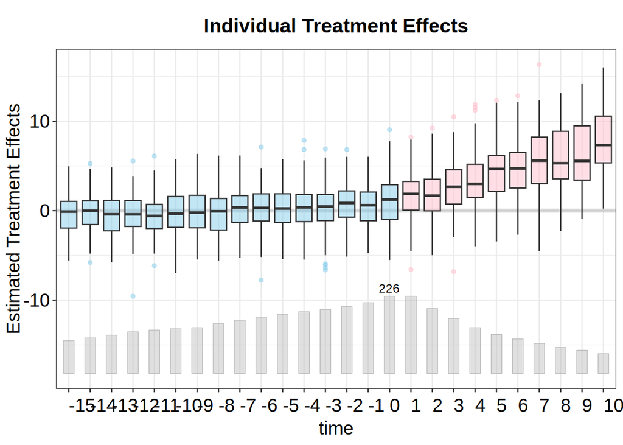

```r
plot(out.fe, type = "box", xlim = c(-15, 10))
```

### Calendar Plots

Calendar plots show the ATT by calendar time. The blue curve is a loess fit with 95% confidence intervals; the red dashed line is the overall ATT.

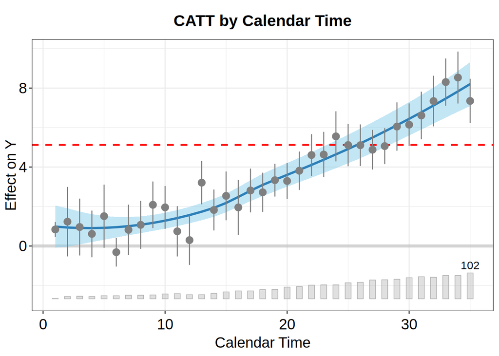

```r
plot(out.fe, type = "calendar", xlim = c(1, 35))
```

### Effect Modification Plot

Setting `type = "hte"` plots $\hat{\delta}_{it}$ against a covariate with a loess fit, visualizing $\hat{\tau}_{\text{em}}^{\text{CME}}(m)$.

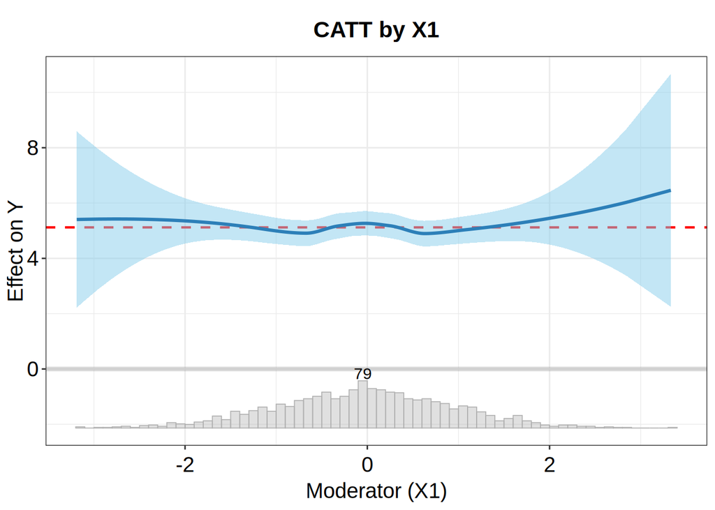

```r
plot(out.fe, type = "hte", covariate = "X1",
     xlab = "Moderator (X1)", ylab = "Effect on Y")
```

In the simulated data, the treatment effect is unrelated to $X_1$, so we expect a flat curve around the ATT.

## Causal Moderation with `cm = TRUE`

### Estimation

To estimate the causal moderation effect, set `cm = TRUE` in `fect()`:

```r
out.cm <- fect(Y ~ D + X1 + X2, data = simdata, index = c("id", "time"),
               method = "fe", force = "two-way", se = TRUE,
               cm = TRUE, parallel = TRUE, cores = 4, nboots = 200)
```

When `cm = TRUE`, **fect** fits two separate imputation models:

- A model for $Y(0)$ using control observations $\to$ `out.cm$est$fit` ($\hat{g}_0$)
- A model for $Y(1)$ using treated observations $\to$ `out.cm$est.cm$fit` ($\hat{g}_1$)

### Comparing Effect Modification vs. Causal Moderation

The default HTE plot shows the effect modification estimate:

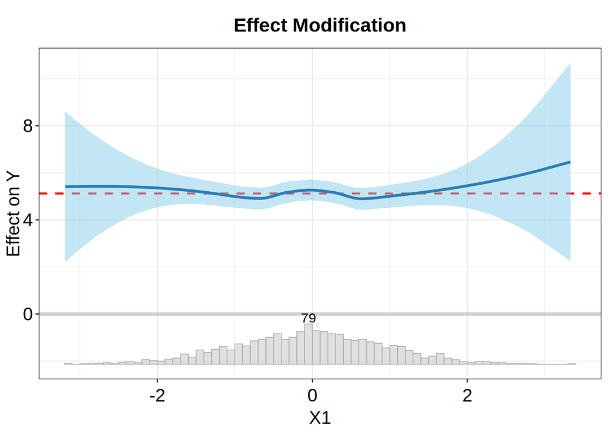

```r
plot(out.cm, type = "hte", covariate = "X1",
     main = "Effect Modification",
     xlab = "X1", ylab = "Effect on Y")
```

By adding `cm = TRUE` to the plot call, we get the causal moderation estimate $\hat{\theta}(m) = \hat{g}_1(m) - \hat{g}_0(m)$:

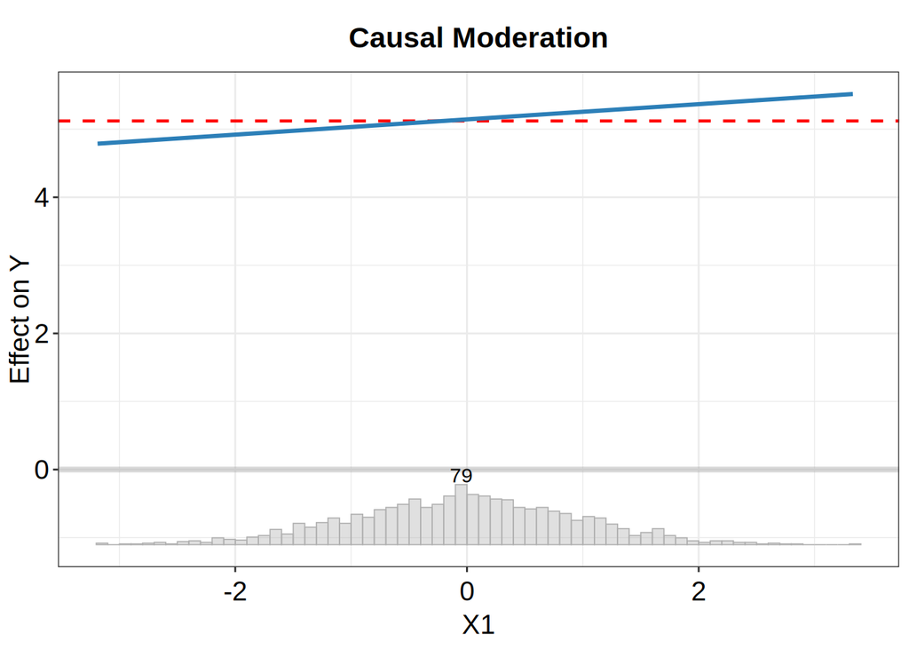

```r
plot(out.cm, type = "hte", covariate = "X1", cm = TRUE,
     main = "Causal Moderation",
     xlab = "X1", ylab = "Effect on Y")
```

When the ignorability assumption for $M$ holds (as in the simulated data), the two curves should be similar. A divergence between the two would indicate that the moderator functions primarily as a proxy (effect modifier) rather than a direct causal driver.

### Scatter Without Smoothing

To inspect the raw relationship, set `loess.fit = FALSE`:

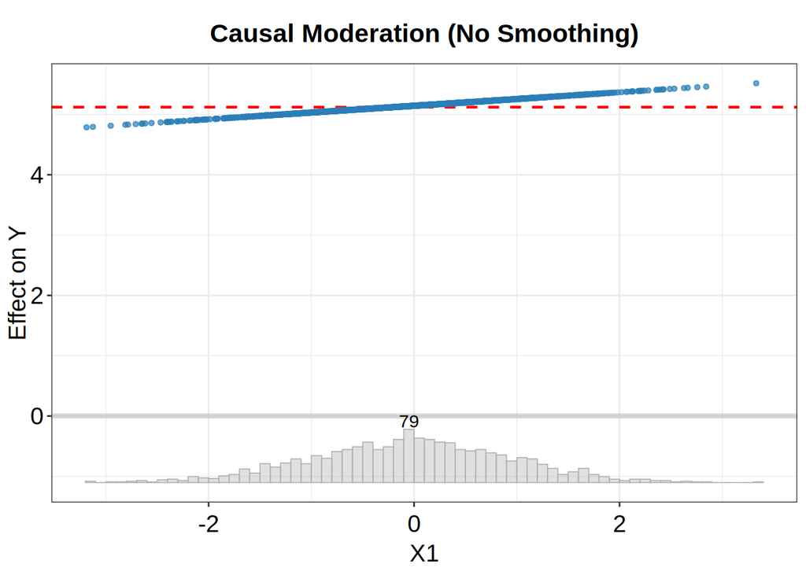

```r
plot(out.cm, type = "hte", covariate = "X1", cm = TRUE, loess.fit = FALSE,
     main = "Causal Moderation (No Smoothing)")
```

## Diagnostic Tools

Valid inference relies on the **conditional parallel trends assumption** (CPTA). We provide several diagnostic tools.

### Placebo Test (Pre-Treatment HTE)

The placebo test applies the HTE estimation to *pre-treatment* periods only. Under CPTA, there should be no relationship between the moderator and the “treatment effect” before treatment onset:

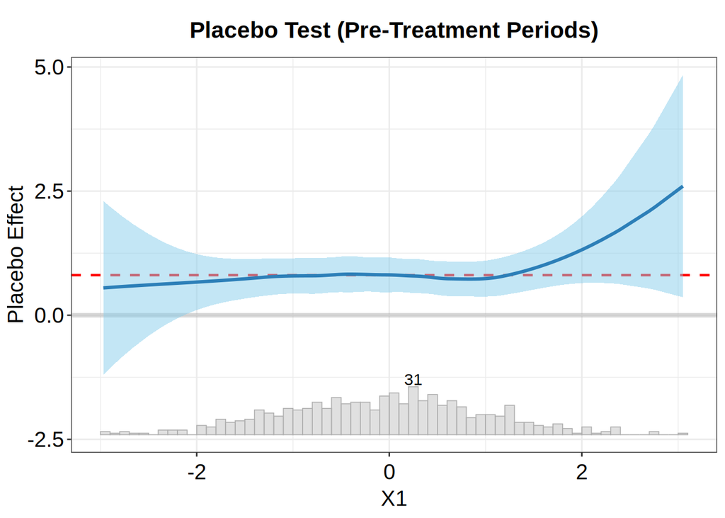

```r
plot(out.cm, type = "hte", covariate = "X1",
     pretreatment = TRUE, num.pretreatment = 3,
     main = "Placebo Test (Pre-Treatment Periods)",
     xlab = "X1", ylab = "Placebo Effect")
```

The `pretreatment = TRUE` option restricts the analysis to the last `num.pretreatment` event-time periods before treatment onset. If the curve is flat around zero, it supports CPTA. A significant non-zero pattern signals that the moderator co-varies with pre-existing trends.

The placebo test can also be applied to the causal moderation estimate:

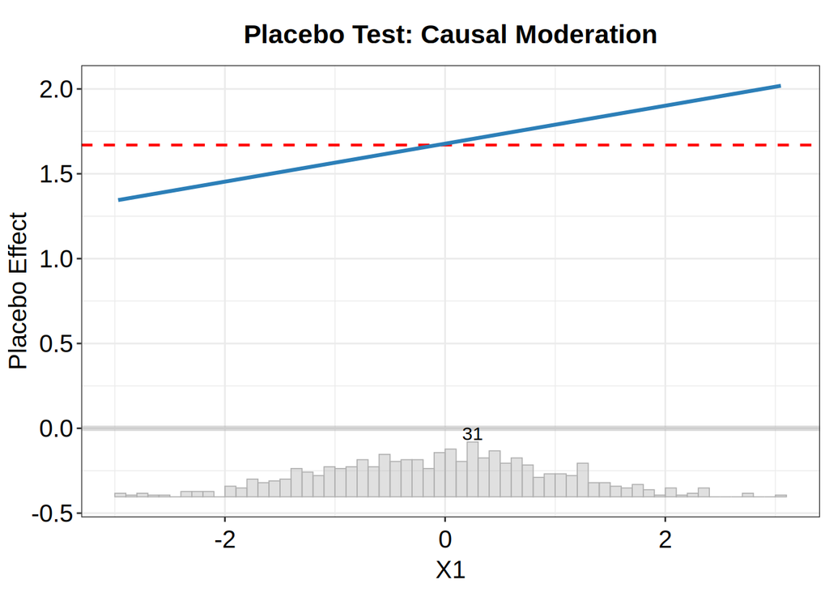

```r
plot(out.cm, type = "hte", covariate = "X1", cm = TRUE,
     pretreatment = TRUE, num.pretreatment = 3,
     main = "Placebo Test: Causal Moderation",
     xlab = "X1", ylab = "Placebo Effect")
```

### Subsample Dynamic Treatment Effects

According to CPTA, parallel trends should hold for any conditional value of the moderator. We can partition the sample by the moderator and estimate separate `fect` models for each subsample:

```r
x1_med <- median(simdata$X1[simdata$D == 1], na.rm = TRUE)

# Subsample: X1 below median
sim_low <- simdata[simdata$X1 < x1_med, ]
out.low <- fect(Y ~ D + X1 + X2, data = sim_low, index = c("id", "time"),
                method = "fe", force = "two-way", se = FALSE)

# Subsample: X1 above median
sim_high <- simdata[simdata$X1 >= x1_med, ]
out.high <- fect(Y ~ D + X1 + X2, data = sim_high, index = c("id", "time"),
                 method = "fe", force = "two-way", se = FALSE)
```

```
## Uncertainty estimates not available.
```

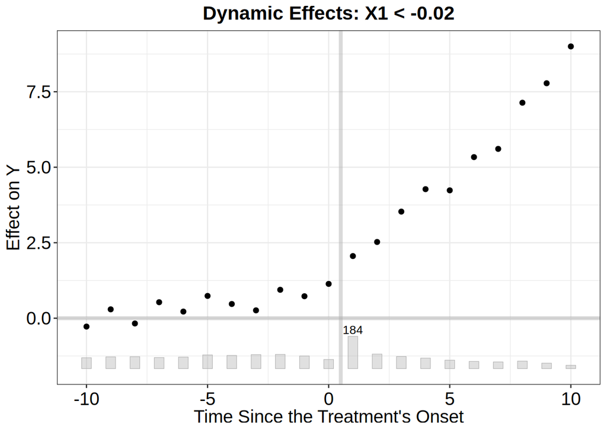

```r
plot(out.low, main = paste0("Dynamic Effects: X1 < ", round(x1_med, 2)),
     ylab = "Effect on Y", xlim = c(-10, 10))
```

```
## Uncertainty estimates not available.
```

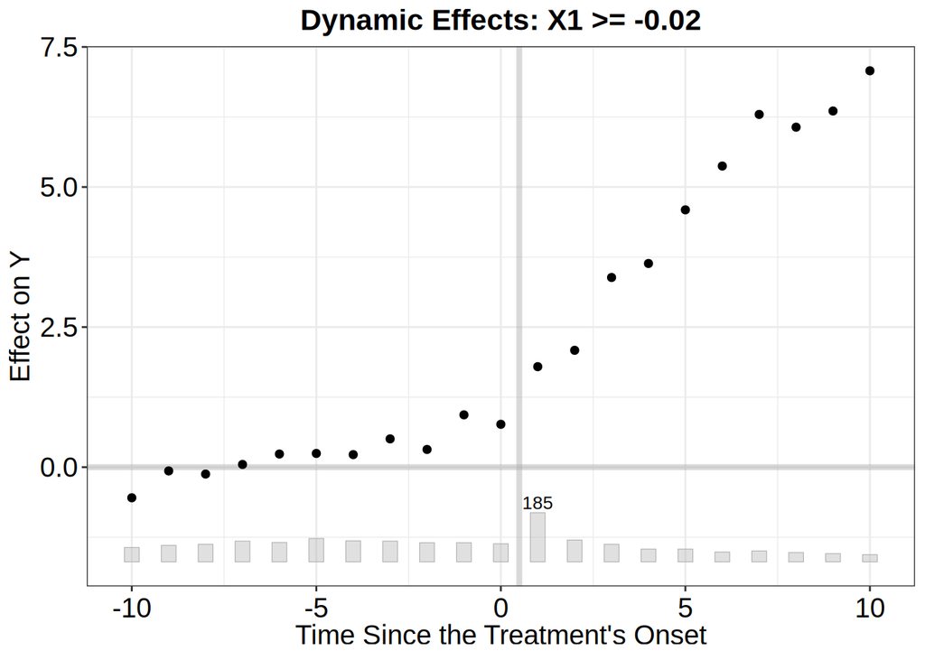

```r
plot(out.high, main = paste0("Dynamic Effects: X1 >= ", round(x1_med, 2)),
     ylab = "Effect on Y", xlim = c(-10, 10))
```

Under CPTA, both subsamples should exhibit flat pre-trends. Opposite-direction violations across subsamples strongly indicate moderator-dependent confounding.

### Subsample Calendar Plots

We can also compare calendar-time treatment effects across subgroups using `type = "calendar"` with the `covariate.value` filter:

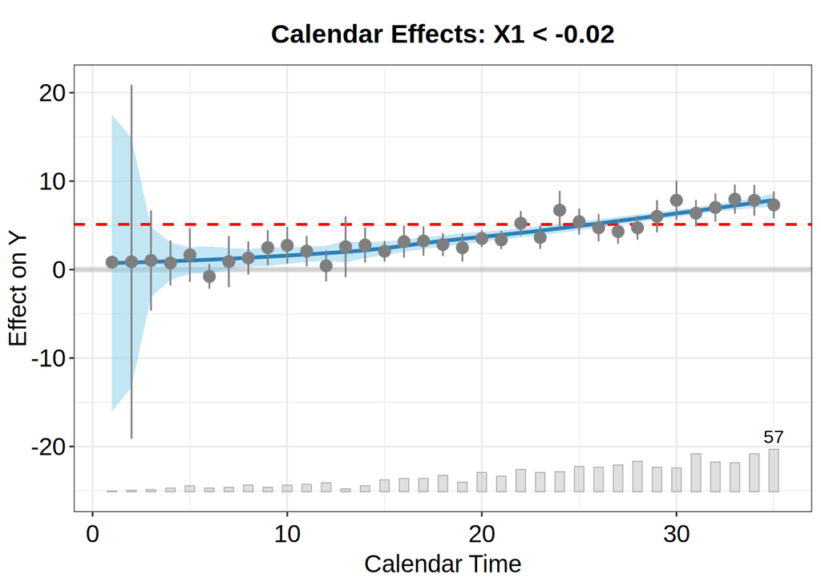

```r
plot(out.cm, type = "calendar",
     covariate = "X1", covariate.value = c(-Inf, x1_med),
     covariate.value.range = TRUE,
     main = paste0("Calendar Effects: X1 < ", round(x1_med, 2)))
```

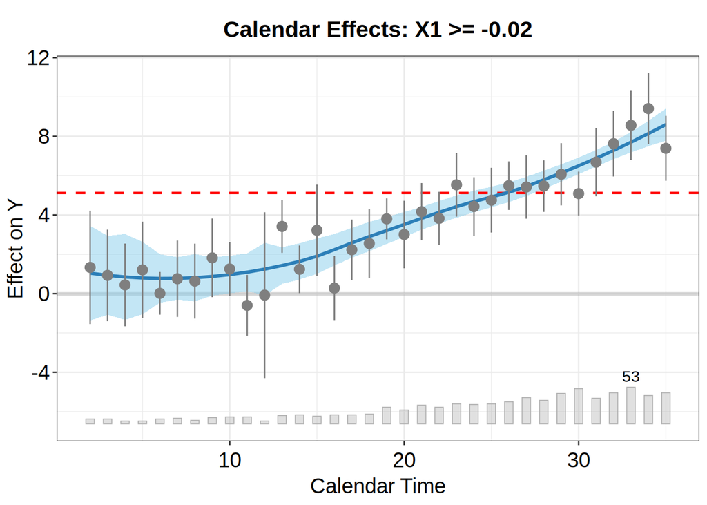

```r
plot(out.cm, type = "calendar",
     covariate = "X1", covariate.value = c(x1_med, Inf),
     covariate.value.range = TRUE,
     main = paste0("Calendar Effects: X1 >= ", round(x1_med, 2)))
```

## Over-Identification Test

The linear CM model assumes $M$ enters linearly. If the true relationship involves $M^2$ or $M \times X$, the linear model is misspecified. `fect_iden()` tests this by regressing residuals on nonlinear terms:
$$H_0:\text{Nonlinear terms have no explanatory power} \quad \Rightarrow
\quad n \times R^2 \sim \chi^2(\text{df})$$

### Usage

```r
iden.test <- fect_iden(out.cm, moderator = "X1")
```

### Results

```r
cat("=== Treated cells (e1) ===\n")
```

```
## === Treated cells (e1) ===
```

```r
cat("  n =", iden.test$e1$n, "\n")
```

```
##   n = 1493
```

```r
cat("  R-squared =", round(iden.test$e1$r2, 4), "\n")
```

```
##   R-squared = 0.0035
```

```r
cat("  Test stat =", round(iden.test$e1$stat, 3), "\n")
```

```
##   Test stat = 5.264
```

```r
cat("  df =", iden.test$e1$df, "\n")
```

```
##   df = 1
```

```r
cat("  p-value =", round(iden.test$e1$p, 4), "\n\n")
```

```
##   p-value = 0.0218
```

```r
cat("=== Control cells (e0) ===\n")
```

```
## === Control cells (e0) ===
```

```r
cat("  n =", iden.test$e0$n, "\n")
```

```
##   n = 5497
```

```r
cat("  R-squared =", round(iden.test$e0$r2, 4), "\n")
```

```
##   R-squared = 6e-04
```

```r
cat("  Test stat =", round(iden.test$e0$stat, 3), "\n")
```

```
##   Test stat = 3.52
```

```r
cat("  df =", iden.test$e0$df, "\n")
```

```
##   df = 1
```

```r
cat("  p-value =", round(iden.test$e0$p, 4), "\n")
```

```
##   p-value = 0.0606
```

- **Large p-values** ($> 0.05$): No evidence against the linear specification.
- **Small p-values** ($< 0.05$): Nonlinear effects present. Consider more flexible specifications.

### Controlling Test Components

```r
# Quadratic terms only (no interactions)
iden.quad <- fect_iden(out.cm, moderator = "X1", interaction = FALSE)
cat("Quadratic-only: p =",
    round(iden.quad$e1$p, 4), "(treated),",
    round(iden.quad$e0$p, 4), "(control)\n")
```

```
## Quadratic-only: p = NA (treated), NA (control)
```

```r
# Interactions only (no quadratics)
iden.inter <- fect_iden(out.cm, moderator = "X1", quadratic = FALSE)
cat("Interaction-only: p =",
    round(iden.inter$e1$p, 4), "(treated),",
    round(iden.inter$e0$p, 4), "(control)\n")
```

```
## Interaction-only: p = 0.0593 (treated), 0.8755 (control)
```

## Interactive Fixed Effects

When the DGP involves latent factors, the FE method may be biased. The IFE method (`method = "ife"`) accommodates unobserved interactive effects:

```r
out.cm.ife <- fect(Y ~ D + X1 + X2, data = simdata, index = c("id", "time"),
                   method = "ife", force = "two-way", r = 2,
                   cm = TRUE, se = FALSE, parallel = TRUE, cores = 4)
```

### Comparing FE and IFE

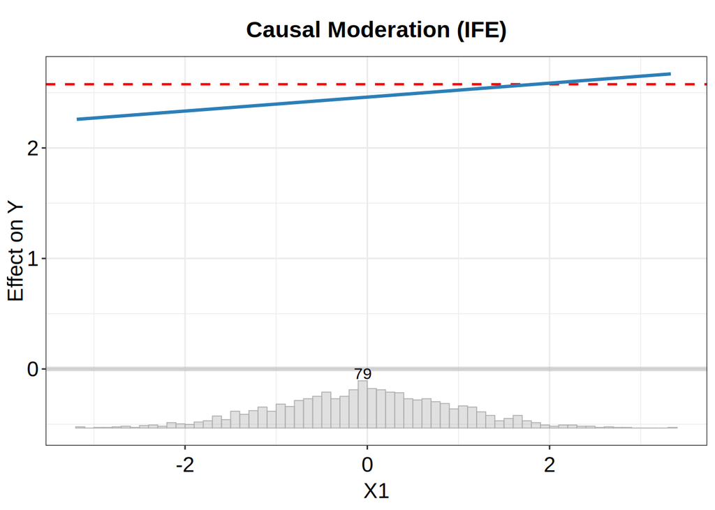

```r
plot(out.cm.ife, type = "hte", covariate = "X1", cm = TRUE,
     main = "Causal Moderation (IFE)")
```

Since `simdata` is generated with interactive fixed effects, the IFE method may provide better estimates:

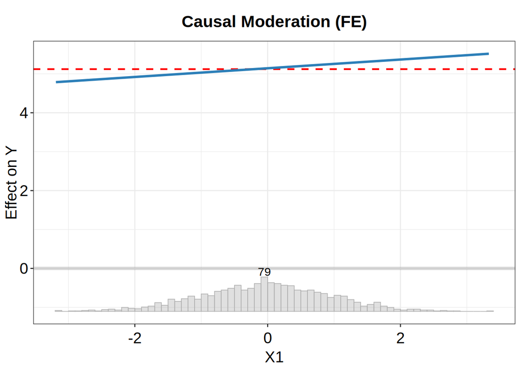

```r
plot(out.cm, type = "hte", covariate = "X1", cm = TRUE,
     main = "Causal Moderation (FE)")
```

The over-identification test helps assess model adequacy:

```r
iden.ife <- fect_iden(out.cm.ife, moderator = "X1")
cat("IFE over-identification test:\n")
```

```
## IFE over-identification test:
```

```r
cat("  Treated p-value:", round(iden.ife$e1$p, 4), "\n")
```

```
##   Treated p-value: 0.2839
```

```r
cat("  Control p-value:", round(iden.ife$e0$p, 4), "\n")
```

```
##   Control p-value: 0.0317
```

## Discrete Moderators

For discrete moderators, the HTE plot automatically produces group-wise estimates:

```r
simdata$Region <- sample(c("North", "South"), nrow(simdata), replace = TRUE)
simdata$Region_num <- ifelse(simdata$Region == "North", 0, 1)
out.discrete <- fect(Y ~ D + X1 + X2 + Region_num, data = simdata,
                     index = c("id", "time"),
                     method = "fe", force = "two-way", se = TRUE,
                     cm = TRUE, parallel = TRUE, cores = 4, nboots = 200)
```

### Effect Modification with Discrete Moderator

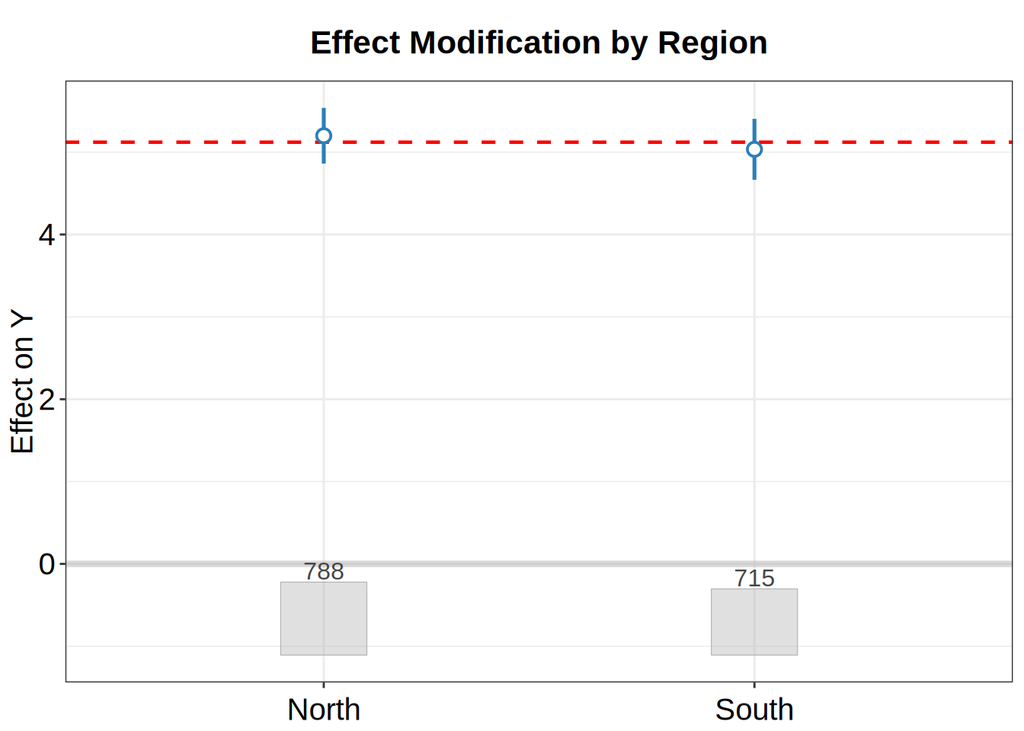

```r
plot(out.discrete, type = "hte", covariate = "Region_num",
     covariate.labels = c("North", "South"),
     xlab = "", ylab = "Effect on Y",
     main = "Effect Modification by Region")
```

### Causal Moderation with Discrete Moderator

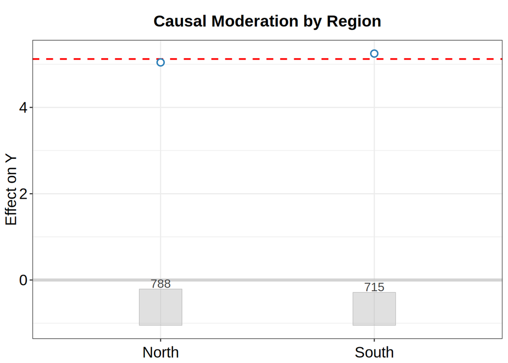

```r
plot(out.discrete, type = "hte", covariate = "Region_num", cm = TRUE,
     covariate.labels = c("North", "South"),
     xlab = "", ylab = "Effect on Y",
     main = "Causal Moderation by Region")
```

Since `Region` is randomly assigned and unrelated to the DGP, both estimates should show no significant heterogeneity.

## Empirical Application: Direct Democracy in Switzerland

We replicate the analysis from @HH2019, who examine how the transition from direct democratic voting to representative committees affects naturalization rates in Swiss municipalities. The `hh2019` dataset contains 1,209 municipalities observed from 1991 to 2009.

```r
data(hh2019)
head(hh2019, 3)
```

```
##   bfs year nat_rate_ord indirect
## 1   1 1991            0        0
## 2   1 1992            0        0
## 3   1 1993            0        0
```

### Baseline Estimation

```r
out.hh <- fect(nat_rate_ord ~ indirect, data = hh2019,
               index = c("bfs", "year"),
               method = "fe", force = "two-way", se = TRUE,
               parallel = TRUE, cores = 4, nboots = 200)
```

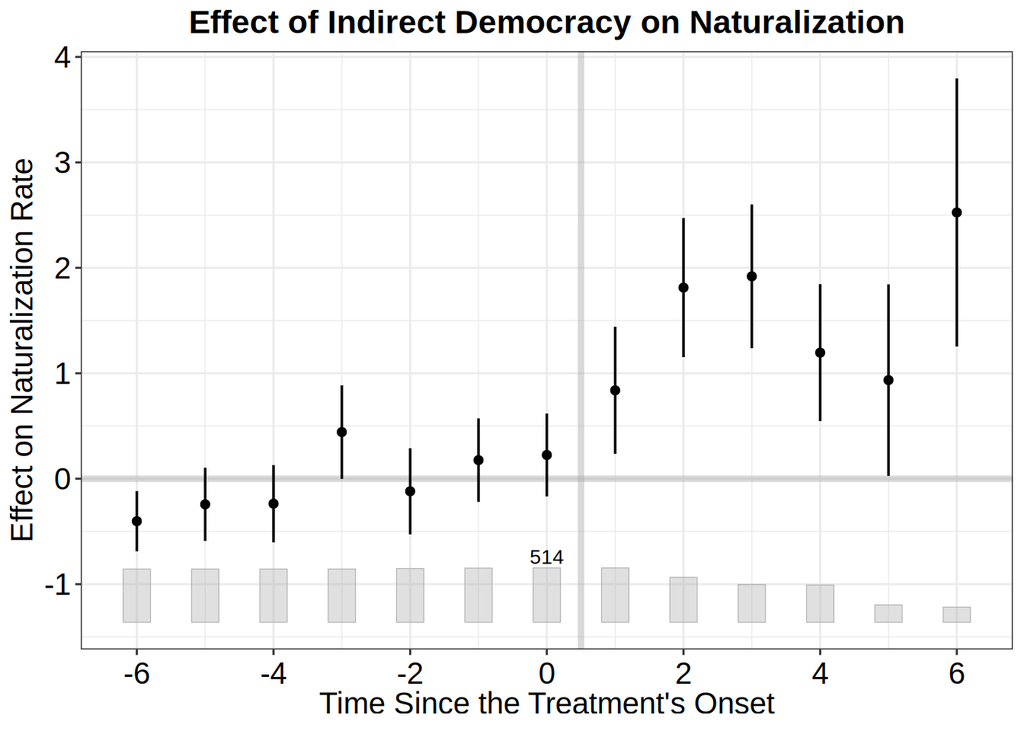

```r
plot(out.hh, main = "Effect of Indirect Democracy on Naturalization",
     ylab = "Effect on Naturalization Rate", xlim = c(-6, 6))
```

The results are consistent with the original findings: switching to representative committees increases naturalization rates.

## Summary of Parameters

| Parameter | Description |
| --- | --- |
| `cm = TRUE` in `fect()` | Estimate causal moderation model (dual imputation) |
| `cm = TRUE` in `plot()` | Plot causal moderation effect $\hat{\theta}(m)$ |
| `type = "hte"` | HTE plot: individual effects vs. covariate |
| `covariate` | Specify the moderator variable |
| `pretreatment = TRUE` | Restrict to pre-treatment periods (placebo test) |
| `num.pretreatment` | Number of pre-treatment periods to include |
| `covariate.value` | Filter observations by moderator values |
| `covariate.value.range = TRUE` | Treat `covariate.value` as range $[\text{lo}, \text{hi}]$ |
| `loess.fit = FALSE` | Scatter only, without loess smoothing |
| `covariate.labels` | Labels for discrete moderator categories |
| `fect_iden()` | Over-identification test for linearity |

## Summary

This chapter introduced the causal moderation framework for heterogeneous treatment effects:

- **Effect modification** describes how the treatment effect varies across observed levels of $M$; it is obtained by projecting individual treatment effects $\hat{\delta}_{it}$ onto the moderator.
- **Causal moderation** answers whether exogenously changing $M$ would alter the treatment effect; it requires separate models for treated and control outcomes (`cm = TRUE`).
- **Diagnostics**: The placebo test (`pretreatment = TRUE`) and subsample event-study plots (`covariate.value`) probe CPTA. The over-identification test (`fect_iden()`) checks linearity.
- **Comparison**: When the EM and CM estimates diverge, $M$ is primarily a proxy; when they converge, $M$ is likely a genuine causal moderator.

For DID-based heterogeneous treatment effect analysis, see @sec-panel.